# Project 1

## 1. Introduction

This data set came from GitHub from this link: https://github.com/chandanverma07/DataSets/blob/master/Car%20details%20v3.csv

```python
import numpy as np
import pandas as pd
import seaborn as sns
import matplotlib.pyplot as plt
import statistics


cars = pd.read_csv("Car details v3.csv")
cars.dropna(inplace=True)
cars.head()
```

|  | name | year | selling_price | km_driven | fuel | seller_type | transmission | owner | mileage | engine | max_power | torque | seats |
| --- | --- | --- | --- | --- | --- | --- | --- | --- | --- | --- | --- | --- | --- |
| 0 | Maruti Swift Dzire VDI | 2014 | 450000 | 145500 | Diesel | Individual | Manual | First Owner | 23.4 kmpl | 1248 CC | 74 bhp | 190Nm@ 2000rpm | 5.0 |
| 1 | Skoda Rapid 1.5 TDI Ambition | 2014 | 370000 | 120000 | Diesel | Individual | Manual | Second Owner | 21.14 kmpl | 1498 CC | 103.52 bhp | 250Nm@ 1500-2500rpm | 5.0 |
| 2 | Honda City 2017-2020 EXi | 2006 | 158000 | 140000 | Petrol | Individual | Manual | Third Owner | 17.7 kmpl | 1497 CC | 78 bhp | 12.7@ 2,700(kgm@ rpm) | 5.0 |
| 3 | Hyundai i20 Sportz Diesel | 2010 | 225000 | 127000 | Diesel | Individual | Manual | First Owner | 23.0 kmpl | 1396 CC | 90 bhp | 22.4 kgm at 1750-2750rpm | 5.0 |
| 4 | Maruti Swift VXI BSIII | 2007 | 130000 | 120000 | Petrol | Individual | Manual | First Owner | 16.1 kmpl | 1298 CC | 88.2 bhp | 11.5@ 4,500(kgm@ rpm) | 5.0 |

## 2. Preproccessing

All columns and items that are not of interest are removed. If there are any missing values, they will be removed. An outlier test is performed on all quantitative columns.

Specifically, columnns for year, fuel, seller_type, transmission, torque, and seats are removed.

```python
cars.dropna(inplace=True)
cars.drop_duplicates(inplace=True)
cars.drop(['year', 'fuel', 'seller_type', 'transmission', 'torque', 'seats','max_power'], axis=1, inplace=True)
cars= cars[cars['owner'] != 'Test Drive Car']

cars.head()
```

|  | name | selling_price | km_driven | owner | mileage | engine |
| --- | --- | --- | --- | --- | --- | --- |
| 0 | Maruti Swift Dzire VDI | 450000 | 145500 | First Owner | 23.4 kmpl | 1248 CC |
| 1 | Skoda Rapid 1.5 TDI Ambition | 370000 | 120000 | Second Owner | 21.14 kmpl | 1498 CC |
| 2 | Honda City 2017-2020 EXi | 158000 | 140000 | Third Owner | 17.7 kmpl | 1497 CC |
| 3 | Hyundai i20 Sportz Diesel | 225000 | 127000 | First Owner | 23.0 kmpl | 1396 CC |
| 4 | Maruti Swift VXI BSIII | 130000 | 120000 | First Owner | 16.1 kmpl | 1298 CC |

```python
def is_outlier(x):
    Q25, Q75 = x.quantile([.25,.75])
    I = Q75 - Q25
    return (x < Q25 - 1.5*I) |  (x > Q75 + 1.5*I)

def IQR_outliers(x):
    IQR = x.quantile(.75) - x.quantile(.25)
    return IQR

outliers_selling_price = cars['selling_price'].loc[is_outlier(cars['selling_price'])]
IQR_selling_price = IQR_outliers(cars['selling_price'])
print("There are " + str(outliers_selling_price.count()) + " outliers in the SELLING PRICE column with an IQR of " + str(IQR_selling_price) + " given that the 25 percentile and 75 percentile are " + str(cars['selling_price'].quantile(.25)) + " and " + str(cars['selling_price'].quantile(.75)) + " respectively.")


outliers_selling_price = cars['km_driven'].loc[is_outlier(cars['km_driven'])]
IQR_selling_price = IQR_outliers(cars['km_driven'])
print("There are " + str(outliers_selling_price.count()) + " outliers in the KILOMETERS DRIVEN   column with an IQR of " + str(IQR_selling_price) + " given that the 25 percentile and 75 percentile are " + str(cars['km_driven'].quantile(.25)) + " and " + str(cars['km_driven'].quantile(.75)) + " respectively.")

cars['mileage_numeric'] = cars['mileage'].str.extract('(\d+.\d+)').astype(float)
outliers_mileage = cars['mileage_numeric'].loc[is_outlier(cars['mileage_numeric'])]
IQR_mileage = IQR_outliers(cars['mileage_numeric'])
print("There are " + str(outliers_mileage.count()) + " outliers in the MILEAGE column with an IQR of " + str(IQR_mileage) + " given that the 25 percentile and 75 percentile are " + str(cars['mileage_numeric'].quantile(.25)) + " and " + str(cars['mileage_numeric'].quantile(.75)) + " respectively.")

cars['engine_numeric'] = cars['engine'].str.extract('(\d+)').astype(int)
outliers_engine = cars['engine_numeric'].loc[is_outlier(cars['engine_numeric'])]
IQR_engine = IQR_outliers(cars['engine_numeric'])
print("There are " + str(outliers_engine.count()) + " outliers in the ENGINE column with an IQR of " + str(IQR_engine) + " given that the 25 percentile and 75 percentile are " + str(cars['engine_numeric'].quantile(.25)) + " and " + str(cars['engine_numeric'].quantile(.75)) + " respectively.")

# Remove rows with outliers in the selling_price column
cars = cars.loc[~cars['selling_price'].isin(outliers_selling_price)]

# Remove rows with outliers in the km_driven column
cars = cars.loc[~cars['km_driven'].isin(outliers_selling_price)]

# Remove rows with outliers in the mileage_numeric column
cars = cars.loc[~cars['mileage_numeric'].isin(outliers_mileage)]
```

```
There are 301 outliers in the SELLING PRICE column with an IQR of 400000.0 given that the 25 percentile and 75 percentile are 250000.0 and 650000.0 respectively.
There are 161 outliers in the KILOMETERS DRIVEN   column with an IQR of 62000.0 given that the 25 percentile and 75 percentile are 38000.0 and 100000.0 respectively.
There are 21 outliers in the MILEAGE column with an IQR of 5.709999999999997 given that the 25 percentile and 75 percentile are 16.8 and 22.509999999999998 respectively.
There are 1207 outliers in the ENGINE column with an IQR of 301.0 given that the 25 percentile and 75 percentile are 1197.0 and 1498.0 respectively.
```

# 3. Summary Data Analysis

Statistical summary of every column using numerical and graphical components is displayed. Correlations between at least 3 pairs of quantitative columns are explored.

### Name column

```python
# Extract the first word (car brand) from the name column
cars['car_brand'] = cars['name'].str.split().str[0]
# Get the most common car brand
most_common_brand = cars['car_brand'].value_counts().idxmax()
# Get the most uncommon car brand
most_uncommon_brand = cars['car_brand'].value_counts().idxmin()
print("Most common car brand:", most_common_brand)
print("Most uncommon car brand:", most_uncommon_brand)
average_cars_per_brand = car_brand_counts.mean()
print("Average number of cars per brand:", average_cars_per_brand)
car_brand_counts = cars['car_brand'].value_counts()
print(car_brand_counts)
```

```
Most common car brand: Maruti
Most uncommon car brand: Lexus
```

[output not shown]

### Selling Price Column

```
count    5.083000e+03
mean     5.844928e+05
std      5.457134e+05
min      2.999900e+04
25%      3.100000e+05
50%      5.030000e+05
75%      7.000000e+05
max      7.200000e+06
Name: selling_price, dtype: float64
```

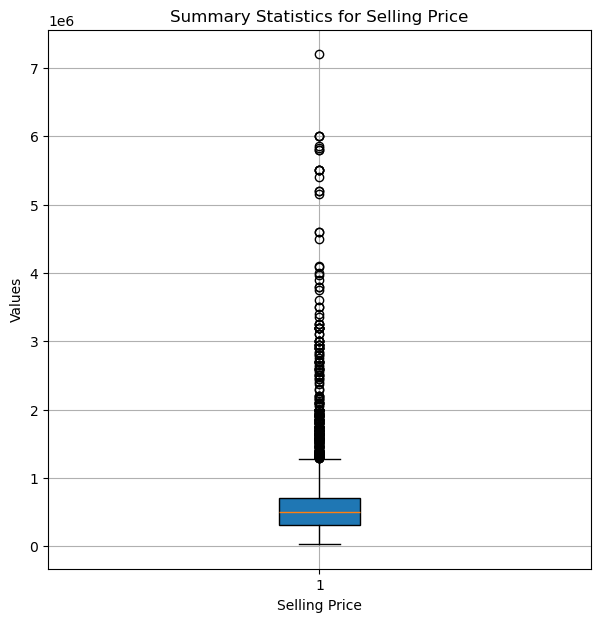

```python
summary_stats = cars['selling_price'].describe()
print(summary_stats)

plt.figure(figsize=(7,7))
plt.boxplot(cars['selling_price'], patch_artist=True)
plt.title('Summary Statistics for Selling Price')
plt.xlabel('Selling Price')
plt.ylabel('Values')
plt.grid(True)
plt.show()
```

### Kilometers Driven Column

```
count      5083.000000
mean      66775.135943
std       39678.236529
min           1.000000
25%       35000.000000
50%       60000.000000
75%       93000.000000
max      192000.000000
Name: km_driven, dtype: float64
```

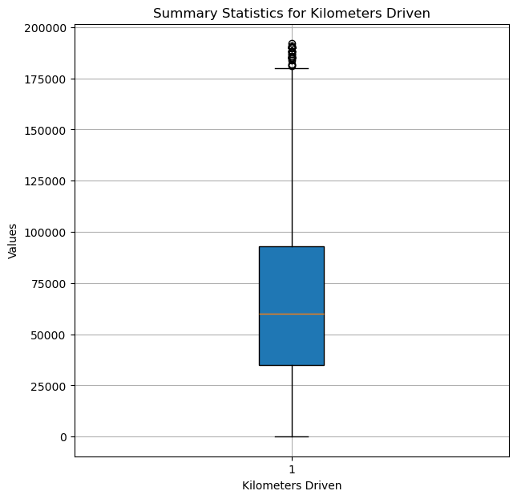

```python
summary_stats_km_driven = cars['km_driven'].describe()
print(summary_stats_km_driven)

plt.figure(figsize=(7,7))
plt.boxplot(cars['km_driven'], patch_artist=True)
plt.title('Summary Statistics for Kilometers Driven')
plt.xlabel('Kilometers Driven')
plt.ylabel('Values')
plt.grid(True)
plt.show()
```

### Owner Column

```python
owner_counts = cars['owner'].value_counts()
print(owner_counts)
```

```
owner
First Owner             3281
Second Owner            1339
Third Owner              348
Fourth & Above Owner     115
Name: count, dtype: int64
```

[output not shown]

[figure not shown]

```python
average_owner = (1*4176 + 2*1888 + 3*493 + 4*155)/(4176 + 1888 + 493 + 155)
print("The Average owner number for the cars in the dataset is :", average_owner)
owner_numbers = [4176, 1888, 493, 155]
mode_owner = statistics.mode(owner_numbers)
print("The mode owner number for the cars in the dataset is :", mode_owner)

x_labels = ['First Owner', 'Second Owner', 'Third Owner', 'Fourth & Above Owner']
y_values = owner_numbers

plt.bar(x_labels, y_values)
plt.xlabel('Owner Categories')
plt.ylabel('Number of Cars')
plt.title('Number of Cars by Owner Category')
plt.show()
```

### Mileage Column

```
count    5083.000000
mean       19.558013
std         3.989036
min         9.000000
25%        16.800000
50%        19.400000
75%        22.540000
max        30.460000
Name: mileage_numeric, dtype: float64
```

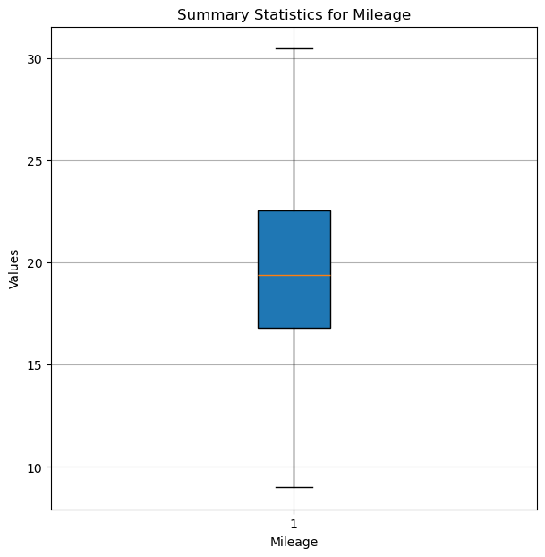

```python
summary_stats_km_driven = cars['mileage_numeric'].describe()
print(summary_stats_km_driven)

plt.figure(figsize=(7,7))
plt.boxplot(cars['mileage_numeric'], patch_artist=True)
plt.title('Summary Statistics for Mileage')
plt.xlabel('Mileage')
plt.ylabel('Values')
plt.grid(True)
plt.show()
```

### Engine Column

```
count    5083.000000
mean     1442.973638
std       489.337612
min       624.000000
25%      1197.000000
50%      1248.000000
75%      1498.000000
max      3604.000000
Name: engine_numeric, dtype: float64
```

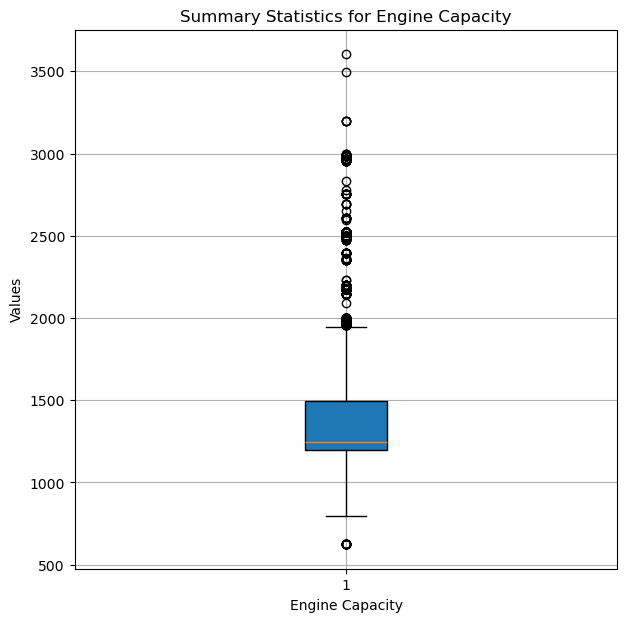

```python
summary_stats_km_driven = cars['engine_numeric'].describe()
print(summary_stats_km_driven)

plt.figure(figsize=(7,7))
plt.boxplot(cars['engine_numeric'], patch_artist=True)
plt.title('Summary Statistics for Engine Capacity')
plt.xlabel('Engine Capacity')
plt.ylabel('Values')
plt.grid(True)
plt.show()
```

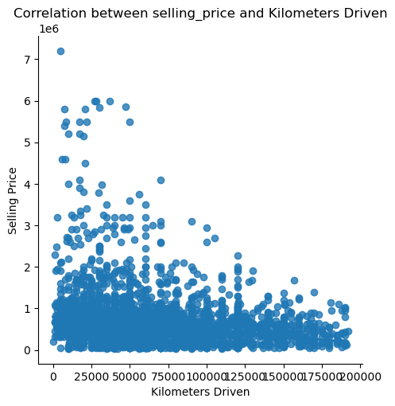

```
Correlation between selling_price and Kilometers Driven: -0.2284780764094624
```

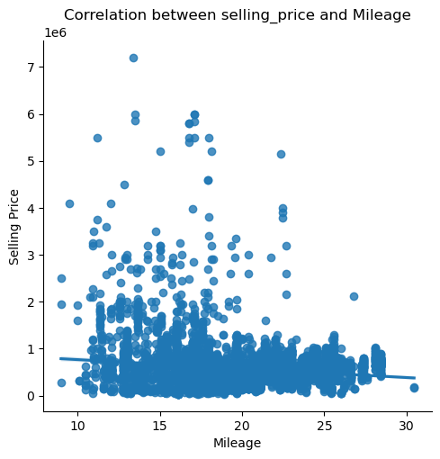

```
Correlation between selling_price and Mileage: -0.13964557945780787
```

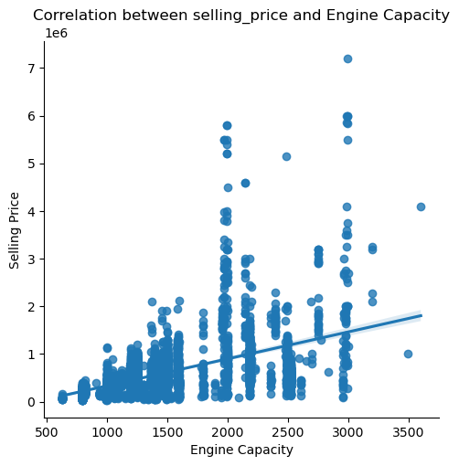

```
Correlation between selling_price and Engine Capacity: 0.5057409656831157
```

```python
correlation_km_driven = cars['selling_price'].corr(cars['km_driven'])
correlation_mileage = cars['selling_price'].corr(cars['mileage_numeric'])
correlation_engine = cars['selling_price'].corr(cars['engine_numeric'])

# Scatter plot with line of best fit for correlation_km_driven
sns.lmplot(x='km_driven', y='selling_price', data=cars)
plt.title('Correlation between selling_price and Kilometers Driven')
plt.xlabel('Kilometers Driven')
plt.ylabel('Selling Price')
plt.show()
print("Correlation between selling_price and Kilometers Driven:", correlation_km_driven)

# Scatter plot with line of best fit for correlation_mileage
sns.lmplot(x='mileage_numeric', y='selling_price', data=cars)
plt.title('Correlation between selling_price and Mileage')
plt.xlabel('Mileage')
plt.ylabel('Selling Price')
plt.show()
print("Correlation between selling_price and Mileage:", correlation_mileage)


# Scatter plot with line of best fit for correlation_engine
sns.lmplot(x='engine_numeric', y='selling_price', data=cars)
plt.title('Correlation between selling_price and Engine Capacity')
plt.xlabel('Engine Capacity')
plt.ylabel('Selling Price')
plt.show()


print("Correlation between selling_price and Engine Capacity:", correlation_engine)
```

Based on our data, we can see that Selling Price and Engine Capacity have the strongest correlation.

### 4. Discussion

Questions or future research:

Question 1: Does Ownership actually have a correlation with the Selling Price of a car (given the notion the First hand is more expensive than Second and so on) and allow us to predict the price within a 5% margin of error?

Question 2: Can combining various variables, namely Kilometers Driven, Ownership, and Engine power allows us to create an equation in which the input of the 3 variables (and others if needed) allow us to create a line of best fit of the price of a car which captures 90% of the cars in our data within a 5% margin of error?